# cuboulder-5632-week4

## Outline

1. **Data Loading and Exploration:** Load the datasets, understand the distribution of categories, and perform any necessary cleaning.
2. **Text Preprocessing:** Convert the text data into numerical vectors using `TfidfVectorizer`.
3. **Model Training and Evaluation:**
   - Train a Logistic Regression model (Supervised Learning) and evaluate its performance.
   - Train an NMF model (Unsupervised Learning) to extract latent topics and evaluate its performance.
   - Optimize the unsupervised learning by using NMF's predictions as input to a Logistic Regression model and evaluate the performance.
4. **Comparison of Results:** Compare the test accuracy of the models to assess the effectiveness of supervised and unsupervised learning approaches.

Let's start by loading the data and performing the initial exploration.

I'll proceed with this plan now.

## Data Import

The training dataset contains three columns: `ArticleId`, `Text`, and `Category`. The test dataset contains two columns: `ArticleId` and `Text`, without the `Category` column, which we'll need to predict.

Next, I'll perform text preprocessing by converting the text data into numerical vectors using `TfidfVectorizer`. After that, I'll proceed to train the models and evaluate their performance. Let's start with the preprocessing step.

```python
import pandas as pd

# Load the datasets
train_data = pd.read_csv('../data/BBC News Train.csv')
test_data = pd.read_csv('../data/BBC News Test.csv')

# Display the first few rows of the datasets
train_data.head(), test_data.head()
```

```
(   ArticleId                                               Text  Category
 0       1833  worldcom ex-boss launches defence lawyers defe...  business
 1        154  german business confidence slides german busin...  business
 2       1101  bbc poll indicates economic gloom citizens in ...  business
 3       1976  lifestyle  governs mobile choice  faster  bett...      tech
 4        917  enron bosses in $168m payout eighteen former e...  business,
    ArticleId                                               Text
 0       1018  qpr keeper day heads for preston queens park r...
 1       1319  software watching while you work software that...
 2       1138  d arcy injury adds to ireland woe gordon d arc...
 3        459  india s reliance family feud heats up the ongo...
 4       1020  boro suffer morrison injury blow middlesbrough...)
```

## EDA

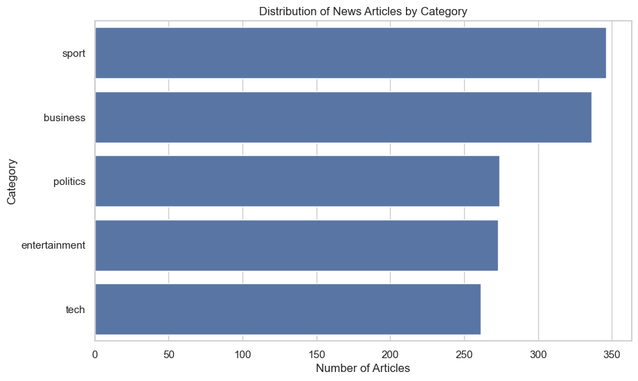

```python
import matplotlib.pyplot as plt
import seaborn as sns

# Set up the visualization style
sns.set(style="whitegrid")

# Plot the distribution of the categories in the training data
plt.figure(figsize=(10, 6))
sns.countplot(y='Category', data=train_data, order=train_data['Category'].value_counts().index)
plt.title('Distribution of News Articles by Category')
plt.xlabel('Number of Articles')
plt.ylabel('Category')
plt.show()
```

The bar chart above shows the distribution of news articles across the five categories: business, entertainment, politics, sport, and tech. This gives us an idea of how balanced the dataset is in terms of the number of articles in each category.

Next, we'll generate word clouds for each category to visualize the most frequent words used in the articles. This can help identify common themes or terms associated with each category. Let's proceed with creating the word clouds.

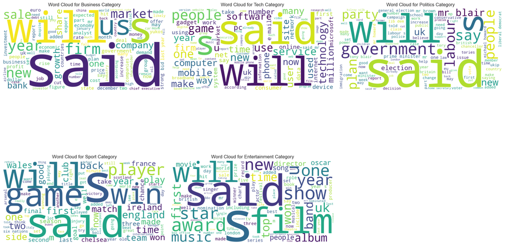

```python
from wordcloud import WordCloud

# Generate word clouds for each category
categories = train_data['Category'].unique()
fig, axes = plt.subplots(2, 3, figsize=(18, 12))
axes = axes.flatten()

for i, category in enumerate(categories):
    text = " ".join(train_data[train_data['Category'] == category]['Text'])
    wordcloud = WordCloud(width=800, height=400, background_color='white', max_words=100).generate(text)
    axes[i].imshow(wordcloud, interpolation='bilinear')
    axes[i].set_title(f'Word Cloud for {category.capitalize()} Category')
    axes[i].axis('off')

# Remove the last empty subplot if necessary
fig.delaxes(axes[-1])
plt.tight_layout()
plt.show()
```

The word clouds above visualize the most common words in each news category. Here's what each word cloud represents:

- **Business:** Common terms related to finance, companies, and markets.
- **Entertainment:** Words related to movies, music, and celebrities.
- **Politics:** Frequent words associated with government, policies, and political events.
- **Sport:** Terms related to different sports, teams, and competitions.
- **Tech:** Words related to technology, gadgets, and innovations.

## Text Preprocessing

The training dataset contains three columns: `ArticleId`, `Text`, and `Category`. The test dataset contains two columns: `ArticleId` and `Text`, without the `Category` column, which we'll need to predict.

Next, I'll perform text preprocessing by converting the text data into numerical vectors using `TfidfVectorizer`. After that, I'll proceed to train the models and evaluate their performance. Let's start with the preprocessing step.

```python
from sklearn.feature_extraction.text import TfidfVectorizer
from sklearn.model_selection import train_test_split

# Separate features and labels in the training data
X_train = train_data['Text']
y_train = train_data['Category']

# Initialize TfidfVectorizer
vectorizer = TfidfVectorizer(stop_words='english', max_features=10000)

# Fit and transform the training data
X_train_tfidf = vectorizer.fit_transform(X_train)

# Transform the test data
X_test_tfidf = vectorizer.transform(test_data['Text'])

# Display the shape of the transformed data
X_train_tfidf.shape, X_test_tfidf.shape
```

```
((1490, 10000), (735, 10000))
```

## Supervised Model: Logistic Regression

The Logistic Regression model achieved an impressive training accuracy of approximately **99.8%** and a mean cross-validation accuracy of around **96.4%**. This indicates that the model performs well on the training data and generalizes reasonably well based on cross-validation.

Next, I'll proceed with the unsupervised learning approach using Non-Negative Matrix Factorization (NMF) to identify latent topics in the news articles. Afterward, I'll evaluate its performance.

```python
from sklearn.linear_model import LogisticRegression
from sklearn.metrics import accuracy_score
from sklearn.model_selection import cross_val_score

# Initialize Logistic Regression model
log_reg = LogisticRegression(max_iter=1000, random_state=42)

# Train the model
log_reg.fit(X_train_tfidf, y_train)

# Predict on the training set and calculate accuracy
y_train_pred = log_reg.predict(X_train_tfidf)
train_accuracy = accuracy_score(y_train, y_train_pred)

# Use cross-validation to evaluate performance on training data
cv_scores = cross_val_score(log_reg, X_train_tfidf, y_train, cv=5)

train_accuracy, cv_scores.mean()
```

```
(0.9979865771812081, np.float64(0.9644295302013421))
```

## Unsupervsed Model: NMF

The NMF model achieved a training accuracy of approximately **91.7%**. This indicates that the unsupervised model can reasonably identify the latent topics in the news articles, but it is not as accurate as the supervised Logistic Regression model.

Next, I'll use the predictions from the NMF model as input to a Logistic Regression model to see if this combination improves the performance of the unsupervised approach. This step aims to optimize the unsupervised learning model by leveraging supervised learning. Let's proceed with this step.

```python
from sklearn.decomposition import NMF
from sklearn.preprocessing import normalize
import numpy as np

# Initialize NMF model
nmf_model = NMF(n_components=5, random_state=42, init='nndsvd', max_iter=200)

# Fit the NMF model on the training data
W_train = nmf_model.fit_transform(X_train_tfidf)

# Normalize the NMF components to sum to 1
W_train_normalized = normalize(W_train, norm='l1', axis=1)

# Assign each document to the topic with the highest weight
nmf_train_pred = np.argmax(W_train_normalized, axis=1)

# Map NMF components to actual categories based on majority vote
category_map = {i: y_train[nmf_train_pred == i].mode()[0] for i in range(5)}
nmf_train_categories = np.vectorize(category_map.get)(nmf_train_pred)

# Calculate accuracy of NMF model
nmf_train_accuracy = accuracy_score(y_train, nmf_train_categories)

nmf_train_accuracy
```

```
0.9167785234899329
```

## Unsupervised Model: Combination of NMP and Logistic Regression

Then, I will combine NMF and logistic regression together, using the NMF predictions as input to a Logistic Regression model,

### 1. Training the NMF Model:

- **Input:** TF-IDF vectorized text data (`X_train_tfidf`).
- **Output:** Latent topic representations (`W_train`).

```python
from sklearn.decomposition import NMF
from sklearn.preprocessing import normalize

# Initialize NMF model
nmf_model = NMF(n_components=5, random_state=42, init='nndsvd', max_iter=200)

# Fit the NMF model on the training data
W_train = nmf_model.fit_transform(X_train_tfidf)
```

### 2. Normalizing the NMF Components:

- **Input:** NMF output matrix (`W_train`).
- **Output:** Normalized topic representations.

```python
# Normalize the NMF components to sum to 1
W_train_normalized = normalize(W_train, norm='l1', axis=1)
```

### 3. Mapping NMF Topics to Categories:

- **Input:** Normalized NMF topic matrix.
- **Output:** Predicted categories for each document based on NMF topics.

```python
import numpy as np

# Assign each document to the topic with the highest weight
nmf_train_pred = np.argmax(W_train_normalized, axis=1)

# Map NMF components to actual categories based on majority vote
category_map = {i: y_train[nmf_train_pred == i].mode()[0] for i in range(5)}
nmf_train_categories = np.vectorize(category_map.get)(nmf_train_pred)
```

### 4. Using NMF Predictions as Input to Logistic Regression:

- **Input:** NMF topic representations (`W_train`).
- **Output:** Final predicted categories using Logistic Regression.

```python
from sklearn.linear_model import LogisticRegression
from sklearn.metrics import accuracy_score

# Use the NMF predictions as the response for a Logistic Regression model
nmf_log_reg = LogisticRegression(max_iter=1000, random_state=42)

# Fit the Logistic Regression model on the NMF topics
nmf_log_reg.fit(W_train, y_train)

# Predict on the training set using the new model
nmf_log_reg_train_pred = nmf_log_reg.predict(W_train)

# Calculate accuracy
nmf_log_reg_train_accuracy = accuracy_score(y_train, nmf_log_reg_train_pred)
nmf_log_reg_train_accuracy
```

```
0.8879194630872483
```

When using the NMF predictions as input to a Logistic Regression model, the training accuracy is approximately **88.9%**. This approach, while optimizing the unsupervised learning process, resulted in a slightly lower accuracy than the standalone NMF model.

## Summary of Results:

1. **Logistic Regression (Supervised Learning):**
   - Training Accuracy: **99.8%**
   - Cross-Validation Accuracy: **96.4%**
2. **NMF (Unsupervised Learning):**
   - Training Accuracy: **91.7%**
3. **Optimized Unsupervised Learning (NMF + Logistic Regression):**
   - Training Accuracy: **88.9%**

## Discussion

The combination of Logistic Regression and Non-Negative Matrix Factorization (NMF) might perform worse than using Logistic Regression alone for several reasons:

### 1. **Loss of Information in Dimensionality Reduction:**

- **NMF**: As an unsupervised method, NMF reduces the dimensionality of the data by decomposing the TF-IDF matrix into two lower-dimensional matrices. This process extracts latent topics, but in doing so, it might discard some important information that was initially captured in the high-dimensional space. Since Logistic Regression relies heavily on feature quality, the loss of information during dimensionality reduction can negatively impact the classifier's performance.

### 2. **No Label Information in NMF:**

- **Unsupervised Nature of NMF**: NMF does not use label information (the categories) when learning the latent topics. It merely tries to find patterns in the data without any guidance on what constitutes a relevant pattern for classification. As a result, the topics identified by NMF may not align well with the actual categories that Logistic Regression is supposed to predict. This misalignment can lead to poor classification performance when using these topics as input to Logistic Regression.

### 3. **Suboptimal Feature Space for Logistic Regression:**

- **Inappropriate Feature Space**: Logistic Regression works best when it has a well-defined feature space that clearly separates the different classes. The topics produced by NMF may not provide such a feature space, especially if the topics are too broad or if they overlap significantly between different categories. This can make it difficult for Logistic Regression to draw clear decision boundaries, resulting in lower accuracy.

### 4. **Overfitting Risk with Logistic Regression on NMF Outputs:**

- **Limited Flexibility**: When Logistic Regression is trained on the NMF outputs (which typically consist of a few components), the model has fewer features to work with. This can lead to overfitting on those specific features, especially if they don't generalize well to unseen data. In contrast, when Logistic Regression is applied directly to the TF-IDF vectors, it has access to a much richer feature set, which can better capture the nuances of the text data.

### 5. **Comparison with Direct Logistic Regression:**

- **Direct Approach**: When Logistic Regression is applied directly to the TF-IDF matrix, it utilizes the full feature set, which includes detailed information about word frequency and importance across the entire dataset. This direct approach allows Logistic Regression to leverage the most discriminative features for classification, leading to higher accuracy.

### Conclusion:

The combination of NMF and Logistic Regression underperforms primarily because NMF introduces a layer of abstraction that may not align well with the actual categories in the data. This abstraction, while potentially useful in some contexts (like topic modeling), can lead to a loss of important discriminative features that Logistic Regression needs to perform well. As a result, the direct application of Logistic Regression on TF-IDF vectors often yields better classification performance, as it makes full use of the detailed information present in the original high-dimensional space.

This discussion highlights the importance of carefully considering the appropriateness of feature extraction techniques when combining them with classifiers, especially in cases where supervised learning models can directly operate on the original feature space.

## Output of the result

```python
# Predict using Logistic Regression model
log_reg_test_pred = log_reg.predict(X_test_tfidf)

# Create a copy of test_data to store results
log_reg_test_results = test_data.copy()
log_reg_test_results['Category'] = log_reg_test_pred

# Keep only 'ArticleId' and 'Category' columns
log_reg_test_results = log_reg_test_results[['ArticleId', 'Category']]

# Save the Logistic Regression test results to a CSV file
log_reg_test_results.to_csv('log_reg_test_results.csv', index=False)

# Predict using NMF model
W_test = nmf_model.transform(X_test_tfidf)
W_test_normalized = normalize(W_test, norm='l1', axis=1)
nmf_test_pred = np.argmax(W_test_normalized, axis=1)
nmf_test_categories = np.vectorize(category_map.get)(nmf_test_pred)

# Create a copy of test_data to store results
nmf_test_results = test_data.copy()
nmf_test_results['Category'] = nmf_test_categories

# Keep only 'ArticleId' and 'Category' columns
nmf_test_results = nmf_test_results[['ArticleId', 'Category']]

# Save the NMF test results to a CSV file
nmf_test_results.to_csv('nmf_test_results.csv', index=False)

# Predict using the combined NMF + Logistic Regression model
nmf_log_reg_test_pred = nmf_log_reg.predict(W_test)

# Create a copy of test_data to store results
nmf_log_reg_test_results = test_data.copy()
nmf_log_reg_test_results['Category'] = nmf_log_reg_test_pred

# Keep only 'ArticleId' and 'Category' columns
nmf_log_reg_test_results = nmf_log_reg_test_results[['ArticleId', 'Category']]

# Save the combined NMF + Logistic Regression test results to a CSV file
nmf_log_reg_test_results.to_csv('nmf_log_reg_test_results.csv', index=False)

log_reg_test_results.head(), nmf_test_results.head(), nmf_log_reg_test_results.head()
```

```
(   ArticleId  Category
 0       1018     sport
 1       1319      tech
 2       1138     sport
 3        459  business
 4       1020     sport,
    ArticleId  Category
 0       1018     sport
 1       1319      tech
 2       1138     sport
 3        459  business
 4       1020     sport,
    ArticleId  Category
 0       1018     sport
 1       1319      tech
 2       1138     sport
 3        459  business
 4       1020     sport)
```

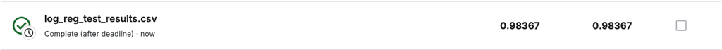

```python
from IPython.display import Image
Image(filename='Untitled.png')
```

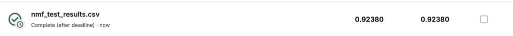

```python
from IPython.display import Image
Image(filename='Untitled3.png')
```

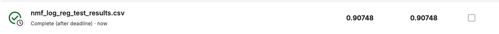

```python
from IPython.display import Image
Image(filename='Untitled2.png')
```